# HWDV6

Author

Carter Wyatt

```r
library(tidyverse)
# Set our ggplot theme from the outset
theme_set(theme_light())
# Read in the data
gender_employment <- read_csv("https://raw.githubusercontent.com/vaiseys/dav-course/main/Data/gender_employment.csv")
# Glimpse at the data
glimpse(gender_employment)
```

```
Rows: 2,088
Columns: 12
$ year                  <dbl> 2013, 2013, 2013, 2013, 2013, 2013, 2013, 2013, …
$ occupation            <chr> "Chief executives", "General and operations mana…
$ major_category        <chr> "Management, Business, and Financial", "Manageme…
$ minor_category        <chr> "Management", "Management", "Management", "Manag…
$ total_workers         <dbl> 1024259, 977284, 14815, 43015, 754514, 44198, 10…
$ workers_male          <dbl> 782400, 681627, 8375, 17775, 440078, 16141, 7287…
$ workers_female        <dbl> 241859, 295657, 6440, 25240, 314436, 28057, 3683…
$ percent_female        <dbl> 23.6, 30.3, 43.5, 58.7, 41.7, 63.5, 33.6, 27.5, …
$ total_earnings        <dbl> 120254, 73557, 67155, 61371, 78455, 74114, 62187…
$ total_earnings_male   <dbl> 126142, 81041, 71530, 75190, 91998, 90071, 66579…
$ total_earnings_female <dbl> 95921, 60759, 65325, 55860, 65040, 66052, 55079,…
$ wage_percent_of_male  <dbl> 76.04208, 74.97316, 91.32532, 74.29179, 70.69719…
```

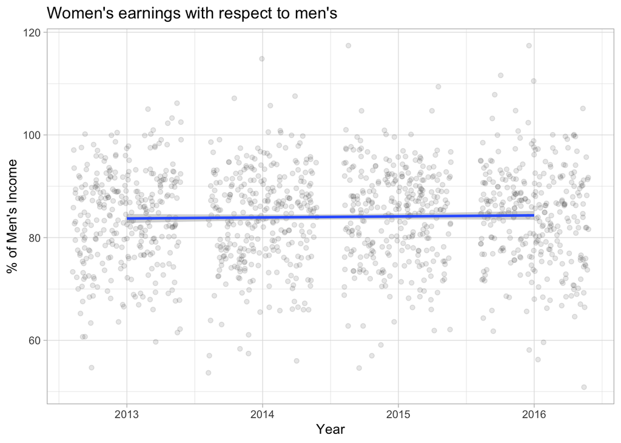

```r
gender_employment%>%
  ggplot(aes(x = year, y = wage_percent_of_male)) +
  geom_jitter(alpha = 0.1) +
  geom_smooth(method = "lm") +
  labs(title = "Women's earnings with respect to men's",
       y = "% of Men's Income",
       x = "Year")
```

```r
library(broom)
```

```r
library(moderndive)
```

## Question 1

```r
gender_employment <- gender_employment %>%
  mutate(major_category = as.factor(major_category),
         major_category = relevel(major_category, ref = "Management, Business, and Financial"))
```

Let’s begin by fitting a model where `wage_percent_of_male` is the outcome variable and the explanatory variables are `year` and `major_category`

DONE

```r
parallel_model <- lm(wage_percent_of_male ~ year + major_category, data = gender_employment)
broom::tidy(parallel_model)
```

```
# A tibble: 9 × 5
  term                                     estimate std.error statistic  p.value
  <chr>                                       <dbl>     <dbl>     <dbl>    <dbl>
1 (Intercept)                              -307.      459.       -0.669 5.04e- 1
2 year                                        0.192     0.228     0.844 3.99e- 1
3 major_categoryComputer, Engineering, an…    6.32      0.946     6.68  3.56e-11
4 major_categoryEducation, Legal, Communi…    5.76      0.985     5.84  6.53e- 9
5 major_categoryHealthcare Practitioners …    5.52      1.10      5.00  6.41e- 7
6 major_categoryNatural Resources, Constr…    4.91      1.24      3.95  8.15e- 5
7 major_categoryProduction, Transportatio…   -1.31      0.960    -1.37  1.72e- 1
8 major_categorySales and Office              3.33      0.858     3.88  1.11e- 4
9 major_categoryService                       6.08      0.885     6.87  1.03e-11
```

Now, fit the model described above and save it as `parallel_model`. Using `tidy()` from the `broom` package, summarize the results. Can we say anything about overall trends by year?

Okay, that was a lot. Now you do some interpretation.

Using the coefficients from your model, calculate the wage percentage of male income for Sales and Office occupations on 2015.

I am unsure.

Now calculate the wage percentage of male income for Service occupations on 2016.

I am unsure.

## Question 2

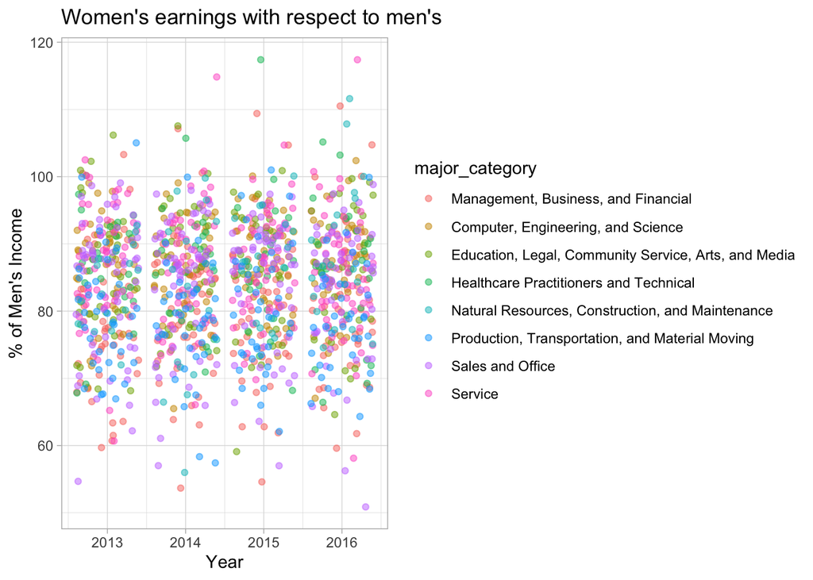

```r
gender_employment |>
  ggplot(aes(x = year, y = wage_percent_of_male, group = major_category, colour = major_category)) + geom_jitter(alpha = 0.5) +
labs(title = "Women's earnings with respect to men's",
       y = "% of Men's Income",
       x = "Year")
```

What do you notice? Is the parallel trends assumption warranted?

I notice that the parallel trends assumption is indeed warranted, and that using color to facet it makes this much easier to understand and interpret.

## Question 3

## Question 4

Given that we have the ability to add interactions to models - i.e. to have slopes vary across categories -, why would we choose to build a model that assumes parallel trends?

We would choose to build a model that assumes parallel trends because it allows for the data to be more descriptive and constant.

## Question 5

## Question 6